# prelim_results

Keana Richards

# 1 Summary:

- Final sample N = 1155
- All graphs represent SE

# 2 Pre-registered analyses:

## 2.1 Primary hypothesis 1:

Women in the unlimited preparation condition will be significantly more likely to compete compared to women in the control condition.

- Model: Two-proportions z-test
1. Predictor(s): Condition
2. Outcome: Willingness to compete
- Women in control condition are significantly more likely to compete, *z* = -2.11, *p* = 0.02

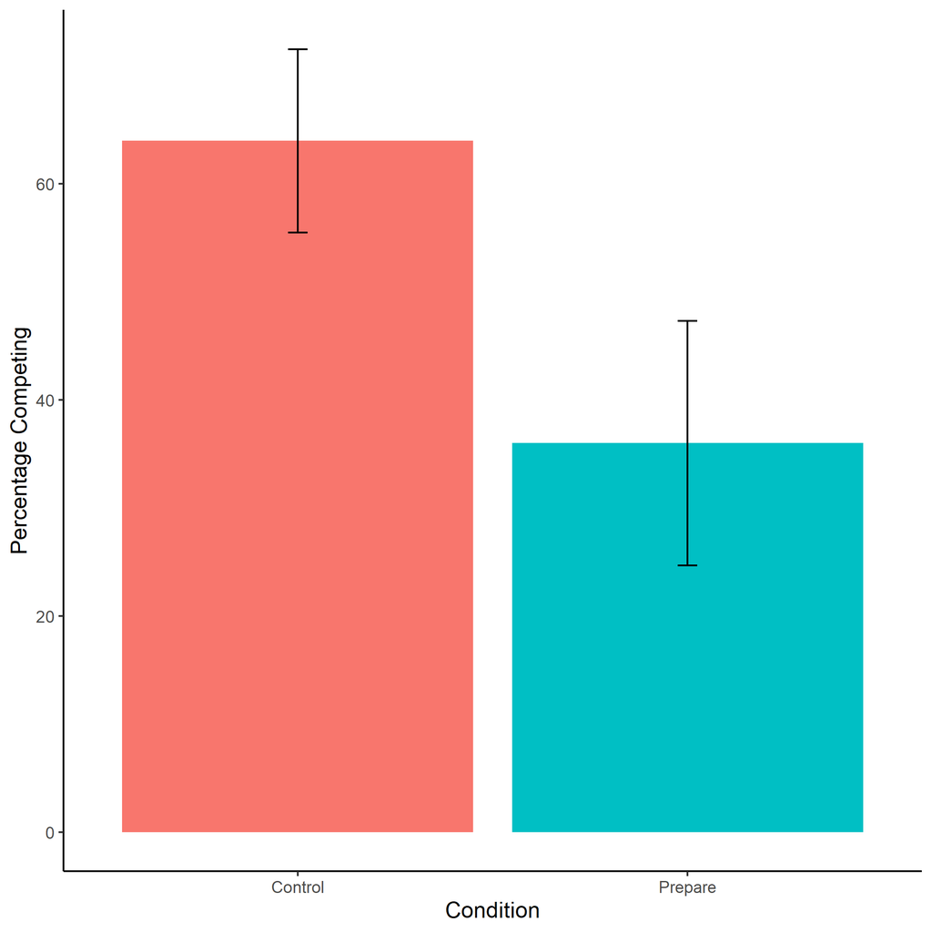

% of women competing based on condition. Error bars represent SE.

Cross-Tabulation, Row Proportions  
comp_choice * condition  
Data Frame: woman

|  | condition | control | pract |  | Total |
| --- | --- | --- | --- | --- | --- |
| comp_choice |  |  |  |  |  |
| piecerate |  | 226 (48.2%) | 243 (51.8%) | 0 ( 0.0%) | 469 (100.0%) |
| tournament |  | 32 (64.0%) | 18 (36.0%) | 0 ( 0.0%) | 50 (100.0%) |
|  |  | 8 (33.3%) | 7 (29.2%) | 9 (37.5%) | 24 (100.0%) |
| Total |  | 266 (49.0%) | 268 (49.4%) | 9 ( 1.7%) | 543 (100.0%) |

## 2.2 Primary hypothesis 2:

Women will attempt more practice problems than men.

- Model: Poisson regression (incrementally adding variables)
1. Predictor(s):
- Regression 1 (Gender)
- Regression 2 (Gender,performance)
- Regression 3 (Gender, performance, risk tolerance, confidence)
2. Outcome: Number of extra practice rounds chosen

|  | extra practice rounds count |  |  | extra practice rounds count |  |  | extra practice rounds count |  |  |
| --- | --- | --- | --- | --- | --- | --- | --- | --- | --- |
| Predictors | Incidence Rate Ratios | CI | p | Incidence Rate Ratios | CI | p | Incidence Rate Ratios | CI | p |
| (Intercept) | 0.13 | 0.11 – 0.16 | **<0.001** | 0.18 | 0.11 – 0.29 | **<0.001** | 0.04 | 0.02 – 0.08 | **<0.001** |
| gender [Woman] | 0.95 | 0.69 – 1.32 | 0.776 | 0.91 | 0.65 – 1.26 | 0.559 | 1.16 | 0.82 – 1.63 | 0.392 |
| task score |  |  |  | 0.99 | 0.99 – 1.00 | 0.155 | 0.99 | 0.98 – 1.00 | 0.131 |
| risk |  |  |  |  |  |  | 1.24 | 1.16 – 1.32 | **<0.001** |
| conf rank |  |  |  |  |  |  | 1.00 | 1.00 – 1.01 | 0.247 |
| Observations | 1141 |  |  | 1111 |  |  | 1110 |  |  |
| R<sup>2</sup> Nagelkerke | 0.000 |  |  | 0.004 |  |  | 0.078 |  |  |

## 2.3 Primary hypothesis 3:

The gender difference in competition choice will be smaller in the treatment condition than the control condition * Model: Logistic regression (incrementally adding variables) a) Predictor(s):

- Regression 1 (Gender, condition, gender*condition)
- Regression 2 (Gender, condition, gender*condition, performance)
- Regression 3 (Gender, condition, gender*condition, performance, risk tolerance, confidence)
2. Outcome: Willingness to compete

|  | comp choice |  |  | comp choice |  |  | comp choice |  |  |
| --- | --- | --- | --- | --- | --- | --- | --- | --- | --- |
| Predictors | Odds Ratios | CI | p | Odds Ratios | CI | p | Odds Ratios | CI | p |
| (Intercept) | 0.27 | 0.20 – 0.35 | **<0.001** | 0.10 | 0.06 – 0.16 | **<0.001** | 0.01 | 0.00 – 0.02 | **<0.001** |
| gender [Woman] | 0.53 | 0.33 – 0.84 | **0.008** | 0.62 | 0.38 – 1.00 | 0.051 | 0.87 | 0.52 – 1.43 | 0.579 |
| condition [pract] | 0.89 | 0.60 – 1.33 | 0.582 | 0.93 | 0.62 – 1.40 | 0.732 | 0.89 | 0.57 – 1.37 | 0.582 |
| gender [Woman] * condition [pract] | 0.59 | 0.28 – 1.20 | 0.148 | 0.57 | 0.27 – 1.18 | 0.131 | 0.60 | 0.28 – 1.30 | 0.198 |
| task score |  |  |  | 1.02 | 1.01 – 1.03 | **<0.001** | 1.02 | 1.01 – 1.02 | **0.001** |
| risk |  |  |  |  |  |  | 1.38 | 1.28 – 1.49 | **<0.001** |
| conf rank |  |  |  |  |  |  | 1.01 | 1.00 – 1.02 | **0.013** |
| Observations | 1116 |  |  | 1111 |  |  | 1110 |  |  |
| R<sup>2</sup> Tjur | 0.024 |  |  | 0.047 |  |  | 0.145 |  |  |

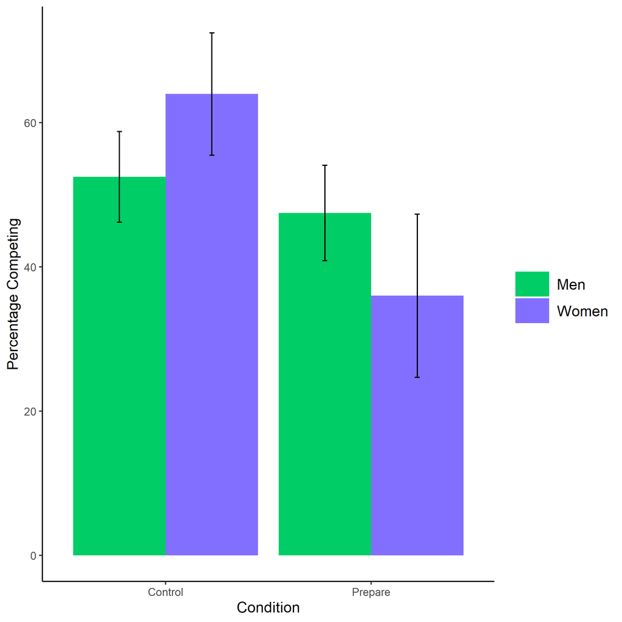

Choice to compete based on condition and gender. Error bars represent SE.

Cross-Tabulation, Row Proportions  
gender * condition  
Data Frame: clean  
Group: comp_choice = piecerate

|  | condition | control | pract | Total |
| --- | --- | --- | --- | --- |
| gender |  |  |  |  |
| Man |  | 237 (49.7%) | 240 (50.3%) | 477 (100.0%) |
| Woman |  | 226 (48.2%) | 243 (51.8%) | 469 (100.0%) |
| Total |  | 463 (48.9%) | 483 (51.1%) | 946 (100.0%) |

Group: comp_choice = tournament

|  | condition | control | pract | Total |
| --- | --- | --- | --- | --- |
| gender |  |  |  |  |
| Man |  | 63 (52.5%) | 57 (47.5%) | 120 (100.0%) |
| Woman |  | 32 (64.0%) | 18 (36.0%) | 50 (100.0%) |
| Total |  | 95 (55.9%) | 75 (44.1%) | 170 (100.0%) |

# 3 Exploratory analyses:

## 3.1 Effect of gender on time spent studying tables

- Model: Linear regression
1. Predictor(s): Gender
2. Outcome: Time spent studying tables

|  | study tables time |  |  |
| --- | --- | --- | --- |
| Predictors | Estimates | CI | p |
| (Intercept) | 19.40 | 11.05 – 27.75 | **<0.001** |
| gender [Woman] | 14.63 | 3.07 – 26.19 | **0.013** |
| comp choice [tournament] | -3.95 | -22.48 – 14.57 | 0.675 |
| gender [Woman] * comp choice [tournament] | -20.91 | -51.58 – 9.76 | 0.181 |
| Observations | 379 |  |  |
| R<sup>2</sup> / R<sup>2</sup> adjusted | 0.025 / 0.018 |  |  |

## 3.2 Effect of gender on choice to study

- Model: Logistic regression
1. Predictor(s): Gender
2. Outcome: Choice to study tables (binary)

|  | study tables binary |  |  |
| --- | --- | --- | --- |
| Predictors | Odds Ratios | CI | p |
| (Intercept) | 0.47 | 0.39 – 0.57 | **<0.001** |
| gender [Woman] | 1.17 | 0.89 – 1.53 | 0.261 |
| comp choice [tournament] | 1.02 | 0.66 – 1.55 | 0.940 |
| gender [Woman] * comp choice [tournament] | 1.19 | 0.57 – 2.47 | 0.649 |
| Observations | 1115 |  |  |
| R<sup>2</sup> Tjur | 0.002 |  |  |

## 3.3 Effect of gender on choice to practice

- Model: Logistic regression
1. Predictor(s): Gender
2. Outcome: Choice to practice (binary)

|  | practice problems binary |  |  |
| --- | --- | --- | --- |
| Predictors | Odds Ratios | CI | p |
| (Intercept) | 0.21 | 0.16 – 0.26 | **<0.001** |
| gender [Woman] | 1.34 | 0.97 – 1.85 | 0.080 |
| comp choice [tournament] | 1.90 | 1.19 – 3.00 | **0.007** |
| gender [Woman] * comp choice [tournament] | 0.42 | 0.16 – 0.98 | 0.052 |
| Observations | 1115 |  |  |
| R<sup>2</sup> Tjur | 0.007 |  |  |

## 3.4 Follow-up questions

### 3.4.1 Do you think men or women in this study correctly solved more multiplication problems on average?

Chi-square Goodness of Fit Test: $\chi^2(2, n = 1155) = 79.16$, $p < .001$

```
##
##           Men No difference         Women
##           320           508           282
```

### 3.4.2 Do you think men or women in this study chose the tournament payment option more often?

Chi-square Goodness of Fit Test: $\chi^2(2, n = 1155) = 997.82$, $p < .001$

```
##
##           Men No difference         Women
##           859           198            53
```

### 3.4.3 On most tasks, do you think men or women generally prepare (i.e., practice and/or study) more?

Chi-square Goodness of Fit Test: $\chi^2(2, n = 1155) = 359.71$, $p < .001$

```
##
##           Men No difference         Women
##           148           309           653
```

### 3.4.4 Do you think men or women spent more time practicing/studying before multiplication task? (only practice condition)

Chi-square Goodness of Fit Test: $\chi^2(2, n = 571) = 191.78$, $p < .001$

```
##
##           Men No difference         Women
##            46           200           312
```

#### 3.4.4.1 filtering question to see if there is a difference in perceptions between genders (aka exclude no diff option)

Chi-square Goodness of Fit Test: $\chi^2(1, n = 358) = 197.64$, $p < .001$

```
##
##   Men Women
##    46   312
```

### 3.4.5 Which task do you think was more helpful in boosting participants’ scores on the paid multiplication task?

Chi-square Goodness of Fit Test: $\chi^2(2, n = 1155) = 808.97$, $p < .001$

```
##
##                                              Multiplication problems
##                                                                  812
##                                                 Subtraction problems
##                                                                   93
## There will not be a difference in performance between the two groups
##                                                                  205
```

# 4 Summary of dataset

### 4.0.1 Data Frame Summary

#### 4.0.1.1 clean

**Dimensions:** 1155 x 32  
**Duplicates:** 13

| No | Variable | Stats / Values | Freqs (% of Valid) | Graph | Missing |
| --- | --- | --- | --- | --- | --- |
| 1 | task_score [numeric] | Mean (sd) : 48 (21) min < med < max: 0 < 44 < 159 IQR (CV) : 26 (0.4) | 107 distinct values |  | 44 (3.8%) |
| 2 | exclude [numeric] | Min : 0 Mean : 0.1 Max : 1 | 0 : 1072 (94.1%) 1 : 67 ( 5.9%) |  | 16 (1.4%) |
| 3 | gender [character] | 1. Man 2. Woman | 612 (53.0%) 543 (47.0%) |  | 0 (0.0%) |
| 4 | gender_other [logical] | All NA’s |  |  | 1155 (100.0%) |
| 5 | task_comp_check1 [character] | 1. 24 2. 32 3. 36 4. 4 x 12 5. 44 6. 46 7. 48 8. 60 9. 84 | 2 ( 0.2%) 1 ( 0.1%) 7 ( 0.6%) 1 ( 0.1%) 2 ( 0.2%) 1 ( 0.1%) 1124 (98.5%) 2 ( 0.2%) 1 ( 0.1%) |  | 14 (1.2%) |
| 6 | task_comp_check2 [numeric] | 1 distinct value | 2 : 17 (100.0%) |  | 1138 (98.5%) |
| 7 | task_comp_check3 [logical] | All NA’s |  |  | 1155 (100.0%) |
| 8 | comp_check_pr1 [character] | 1. $.25 2. $0 3. $1.20 4. $12 | 6 ( 0.5%) 2 ( 0.2%) 236 (20.9%) 886 (78.4%) |  | 25 (2.2%) |
| 9 | comp_check_pr2 [character] | 1. $14 | 243 (100.0%) |  | 912 (79.0%) |
| 10 | comp_check_comp1 [character] | 1. $.25 2. $0 3. $2 4. $24 | 7 ( 0.6%) 25 ( 2.2%) 45 ( 4.0%) 1050 (93.2%) |  | 28 (2.4%) |
| 11 | comp_check_comp2 [character] | 1. $28 | 75 (100.0%) |  | 1080 (93.5%) |
| 12 | comp_check_comp3 [character] | 1. $.25 2. $0 3. $2 4. $24 | 15 ( 1.3%) 943 (84.0%) 27 ( 2.4%) 138 (12.3%) |  | 32 (2.8%) |
| 13 | comp_check_comp4 [character] | 1. $0 | 175 (100.0%) |  | 980 (84.8%) |
| 14 | task_comp_check_acc [numeric] | Min : 0 Mean : 0 Max : 1 | 0 : 1124 (98.5%) 1 : 17 ( 1.5%) |  | 14 (1.2%) |
| 15 | pay_comp_check_acc [numeric] | Mean (sd) : 0.4 (0.7) min < med < max: 0 < 0 < 3 IQR (CV) : 1 (1.6) | 0 : 760 (67.7%) 1 : 253 (22.5%) 2 : 87 ( 7.7%) 3 : 23 ( 2.0%) |  | 32 (2.8%) |
| 16 | n_comp_wrong [numeric] | Mean (sd) : 0.5 (0.7) min < med < max: 0 < 0 < 3 IQR (CV) : 1 (1.6) | 0 : 747 (66.5%) 1 : 264 (23.5%) 2 : 88 ( 7.8%) 3 : 24 ( 2.1%) |  | 32 (2.8%) |
| 17 | conf_rank [numeric] | Mean (sd) : 54 (23) min < med < max: 0 < 60 < 100 IQR (CV) : 30 (0.4) | 11 distinct values |  | 45 (3.9%) |
| 18 | better_gender_guess [character] | 1. Men 2. No difference 3. Women | 320 (28.8%) 508 (45.8%) 282 (25.4%) |  | 45 (3.9%) |
| 19 | perc_task_gender_pract [character] | 1. Men 2. No difference 3. Women | 46 ( 8.2%) 200 (35.8%) 312 (55.9%) |  | 597 (51.7%) |
| 20 | perc_gender_comp [character] | 1. Men 2. No difference 3. Women | 859 (77.4%) 198 (17.8%) 53 ( 4.8%) |  | 45 (3.9%) |
| 21 | MC [character] | 1. Multiplication problems 2. Subtraction problems 3. There will not be a diffe | 812 (73.2%) 93 ( 8.4%) 205 (18.5%) |  | 45 (3.9%) |
| 22 | risk [numeric] | Mean (sd) : 4.6 (2.6) min < med < max: 0 < 5 < 10 IQR (CV) : 5 (0.6) | 11 distinct values |  | 45 (3.9%) |
| 23 | perc_gen_gender_pract [character] | 1. Men 2. No difference 3. Women | 148 (13.3%) 309 (27.8%) 653 (58.8%) |  | 45 (3.9%) |
| 24 | age [numeric] | Mean (sd) : 39 (12) min < med < max: 19 < 36 < 78 IQR (CV) : 15 (0.3) | 58 distinct values |  | 45 (3.9%) |
| 25 | education [character] | 1. Associate’s degree (inclu 2. Bachelor’s degree (BA, BS 3. Doctorate degree (PhD, Ed 4. High school graduate (dip 5. High school graduate (GED 6. Less than high school 7. Master’s degree (MA, MS, 8.… | 113 (10.2%) 443 (39.9%) 12 ( 1.1%) 111 (10.0%) 28 ( 2.5%) 7 ( 0.6%) 138 (12.4%) 12 ( 1.1%) 246 (22.2%) |  | 45 (3.9%) |
| 26 | condition [character] | 1. control 2. pract | 570 (50.0%) 571 (50.0%) |  | 14 (1.2%) |
| 27 | comp_choice [character] | 1. piecerate 2. tournament | 946 (84.8%) 170 (15.2%) |  | 39 (3.4%) |
| 28 | extra_practice_rounds_count [numeric] | Mean (sd) : 0.1 (0.8) min < med < max: 0 < 0 < 18 IQR (CV) : 0 (6.2) | 0 : 1076 (94.3%) 1 : 34 ( 3.0%) 2 : 16 ( 1.4%) 3 : 6 ( 0.5%) 4 : 1 ( 0.1%) 5 : 4 ( 0.4%) 7 : 1 ( 0.1%) 8 : 2 ( 0.2%) 18 : 1 ( 0.1%) |  | 14 (1.2%) |
| 29 | study_tables_binary [factor] | 1. No 2. Yes | 754 (66.3%) 384 (33.7%) |  | 17 (1.5%) |
| 30 | practice_problems_binary [factor] | 1. No 2. Yes | 907 (79.8%) 230 (20.2%) |  | 18 (1.6%) |
| 31 | study_tables_time [numeric] | Mean (sd) : 25 (53) min < med < max: 0 < 13 < 813 IQR (CV) : 18 (2.1) | 382 distinct values |  | 771 (66.8%) |
| 32 | log_study_tables_time [numeric] | Mean (sd) : -Inf (NaN) min < med < max: -Inf < 2.5 < 6.7 IQR (CV) : 1.3 (NaN) | 382 distinct values |  | 771 (66.8%) |

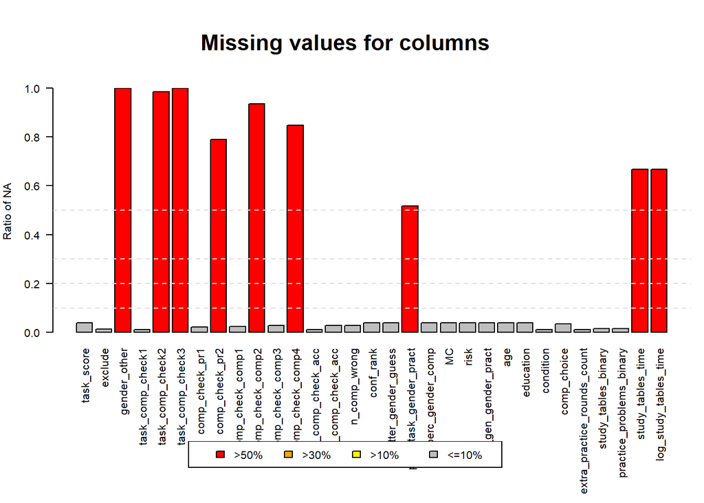

```
##    column_index                 column_name number_of_NAs ratio_of_NA
## 1             1                  task_score            44       0.038
## 2             2                     exclude            16       0.014
## 3             4                gender_other          1155       1.000
## 4             5            task_comp_check1            14       0.012
## 5             6            task_comp_check2          1138       0.985
## 6             7            task_comp_check3          1155       1.000
## 7             8              comp_check_pr1            25       0.022
## 8             9              comp_check_pr2           912       0.790
## 9            10            comp_check_comp1            28       0.024
## 10           11            comp_check_comp2          1080       0.935
## 11           12            comp_check_comp3            32       0.028
## 12           13            comp_check_comp4           980       0.848
## 13           14         task_comp_check_acc            14       0.012
## 14           15          pay_comp_check_acc            32       0.028
```

[output cut: 17 more lines]